# A "league of nations on the pitch": An analysis of overseas players in the English Premier League and their effect

## Context

The English Premier League (EPL) was established in 1992 after the teams making up the then English Football League Division One decided to break away from the Football League, and take advantage of the huge sums of money being offered to them as part of a televised football deal. It was later to become the most-watched sports league in the world, broadcasting to 212 territories, and a potential TV audience of 4.7 billion people. <sup>1</sup>

Following the Bosman ruling in 1995<sup>2</sup> and the fluid international transfer market that it gave birth to, the EPL witnessed an influx of overseas players wanting to compete in this new, exciting league. In 2013, the EPL's own website displayed the following:

> "The Barclays Premier League is now the world’s league... It has become **a league of nations on the pitch** too. In 1992 there were only 11 non-British or Irish footballers in the Premier League. These days there are, on average, around 70 nationalities running on to the pitch in the Premier League." <sup>3</sup>

However, this is not seen as a positive by everyone involved with, or following, the EPL. Some believe that this has had a negative effect on the development of *indigenous* football players; that it has been dentrimental to grassroots football and club academies, where young players are now competing against players from all over the world for that golden ticket - a club contract. Ultimately, many talk of its negative effect on the prospects of the English national team. As a result, the EPL introduced the Homegrown Player Rule for the start of the 2010/11 football season. This initiative stated that each club squad of 25 players must contain at least eight homegrown players. A homegrown player is a player who has been under contract with an English team for at least three years before turning 21. <sup>4</sup>

It is my intention to analyse the member teams of the Premier League, and the league itself, since it's inception in 1992, to see how the competition's squads have changed. Was the EPL a "league of nations" by 2013, and how was that different to 1992, and when Liverpool won the Premier League title in 2019/2020? Have those teams that have embraced the overseas transfer market had more success, more than those sides that have attempted to nurture more homegrown talent through their academies. Have clubs in London seen more of an influx of overseas players than, for example, those at the opposite end of the country in the North West? And, finally, is it the names of overseas players that are lauded by teams' fans when they discuss their greatest Premier League goal scorers or creative geniuses?

## Premier League data

### Locating the data

Obtaining the Premier League data required for my purposes was not as simple as I first thought. Football data tends to centre around, as one would expect, results, goal scorers, league positions, etc. What I needed was squad information, including key player stats, and - of course - nationality. Further, detailed Premier League information is often not free, it being such a popular league - as discussed earlier - with a lot of website and application opportunities, including those that make money such as gambling sites.

However, after a lot of searching and researching, I came across **FBRef**, a part of the Sport Reference group of websites that also publish statistics for American Football and Baseball, amongst others <sup>5</sup>. Their websites offer extensive and detailed information on all aspects of your searched-for-sport, most imporantly for me, a detailed breakdown of every club's squad players, including nationality, for every EPL season since it's birth in 1992.

### How to store the data

I soon realised that to perform any kind of successful analysis around the questions that I raised above, I need a lot of data. There have been 28 Premier League seasons, not including the current season (I had decided not to look at the current season as it is ongoing, and therefore any analysis on the effect of non-English players on this competition would be incomplete). The first three seasons of the EPL were contested by twenty-two teams, while season 1995/96, and all subsequent seasons, have had twenty members. I therefore required the player information of 566 Premier League squads (3 seasons of 22 teams, plus 25 seasons of 20 teams).

These 566 squads would have obvious relations - the club they belonged to, and the season in which they competed. This, coupled with the fact that - being a JavaScript developer - I work day-to-day with data in JSON format, made me initially decide upon scraping the data from FBRef and storing it as a JavaScript object, with each season being a primary key, for example:

`{ '2008/09': [ { 'club': 'Newcastle Utd', ... } ... '2009/10': [ { 'club': 'Newcastle Utd', ... } ... ] }`

At first, this seemed to be a successful way of storing the data. Viewing each individual season was simple, as was drilling down into a team within that season. However, it soon became apparent that while the relationships between a squad member and his team, and the relationship between his team and the season in which it played, where easy to inspect, many relationships were not. Collating a club's squad information for a team across multiple seasons became more difficult; finding the number of French players across all clubs in a season was time consuming; studying any drop of *homegrown* players from 2010/11 was confusing.

Further, the objects were becoming too big, as I decided to add more and more properties. To test whether playing non-English players had an effect on the success or failure of a team, I needed to store each individual player's statistics - such as goals score, assists, etc - and the player's JSON object, in particular, became complicated and unwieldy.

It was clear, then, that JSON wasn't the answer, and I decided upon the CSV format. Furthermore, to mitigate the loss of my JSON data relationships, I also decided to scrape all of the data into one CSV document, as opposed to multiple documents storing, for example, a single season or individual club. I was confident that, despite it being a large dataset, storing it in CSV would still produce a manageable file size, and I wasn't disappointed when I completed my first web scrape.

### Getting the data

Those CSV advantages aside, the process, I discovered, was slow. Each squad on the FBRef website is displayed on an individual page - as stated before, on *566* individual pages. Those detailed squad pages have no discernible pattern in their URL, all containing a seemingly random eight character string. The only way to successfully navigate to those pages, therefore, was to follow individual links from each EPL club name in the final position table for each season (all twenty eight seasons). Again, these season pages had no discernible format in their URL and so, again, the only way to navigate to each season was to follow a link from a list of all EPL seasons-to-date on the FBRef Premier League Seasons *index* page (https://fbref.com/en/comps/9/history/Premier-League-Seasons).

The process, therefore, looked like this:

1. Load Premier League index page.
2. Locate required season page hyperlink.
3. Follow hyperlink and load required season page.
4. Locate club's squad hyperlink.
5. Follow hyperlink and load required squad page.
6. Locate squad player and scrape, clean and save his data.
7. Repeat step 6 for each player in the squad.
8. Repeat steps 4 - 6 for each club competing in that season/
9. Repeat steps 1 - 7 for each season that has been played and completed.

It was clear, then, that I only wanted to carry out these steps when absolutely necessary. As a result, the first time the script was run, the data is saved as a local CSV file. From that point on, we only run through the process of scraping the data if the locally saved CSV file can't be found - we have the luxury of working with data that won't change and therefore the locally saved CSV file won't ever become stale. Further, I set up the local filename in such a way that I could force a new scrape if I so wished, without having to rename, move or delete the most recent file.

```python
from markupsafe import Markup
from bokeh.io import output_notebook, show
```

```python
from urllib.request import urlopen
from bs4 import BeautifulSoup
import os
import csv
import operator
import pandas as pd
import geopandas as gpd
import descartes
import matplotlib.pyplot as plt
%matplotlib inline
import matplotlib
import json

from markupsafe import Markup

from bokeh.io import output_notebook, show
from bokeh.models import (CDSView, ColorBar, ColumnDataSource,
                          CustomJS, CustomJSFilter,
                          GeoJSONDataSource, HoverTool,
                          LinearColorMapper, Slider)
from bokeh.layouts import column, row, widgetbox
from bokeh.palettes import Magma256
from bokeh.plotting import figure
output_notebook()

localFilesVersion = '_' + str(1) # Allows us to force a refetch
localDataFile = 'premierLeagueData' + localFilesVersion + '.csv'
```

After running through the process a number of times, making tweaks to the data I wanted, cleaning it in different ways, removing data points, adding data points, etc, I decided to add some configuration settings to my script. Firstly, anyone running the scraping function can view detailed progress information, giving them an insight on how many seasons, clubs and players have been read, and how many are remaining. Further, that user can also determine how many seasons to analyse, and how many teams in each season to inspect. You can, for example, just look at the top three seasons, for the last three seaons played. This became invaluable for development and testing purposes.

```python
displayProgressWhileScraping = True
numOfSeasonsToAnalyse = 28 # How many full seasons to analyse, going back from last season (max 28)
numOfTeamsToAnalyse = 22 # Number of teams, from the top, to analyse (max 22, 20 for 25 of the 28 seasons)
```

I kept the saving of the data separate from the `getPremierLeagueData` function, allowing that function to be concerned only with scraping and cleaning the information.

```python
def addRowToCSV(file, row):
    with open(file, 'a+', newline='') as file:
        writer = csv.writer(file)
        writer.writerow(row)
```

Using the principle of separation of concerns, as I had to inspect and scrape seasons, clubs and players, I created a function for each. The following is used to gather all the necessary information for all - or a specific number of - Premier League seasons, found after opening the Premier League Seasons index page:

```python
def getAndCleanSeasons(url, numSeasons):
    # Open the page
    page = urlopen(url).read()
    # Find the table containing all of the Premier League seasons
    soup = BeautifulSoup(page)
    table = soup.find(id='seasons')
    tbody = table.find('tbody')
    # Get the season links
    seasonCells = tbody.find_all('th', attrs={'data-stat': 'season'})
    # Remove the first one as we only want FULL/COMPLETED seasons
    seasonCells.pop(0);
    # How many seasons to analyse?
    totalSeasons = numSeasons if numSeasons <= len(seasonCells) else len(seasonCells)
    seasons = seasonCells[:totalSeasons]
    # Return the required seasons
    return seasons
```

Next, we need to go into each individual season, after following the link to the season page, and locate each team that competed. Again, we return all teams or a specified amount of teams. We store the season name, and return the name and collected teams for that season.

```python
def getAndCleanSeason(domain, season, numTeams):
    # Get the season name and link
    seasonLink = season.find('a').get('href')
    name = season.text.strip()
    # Open season page
    page = urlopen(domain + seasonLink).read()
    soup = BeautifulSoup(page)
    # Get the results table
    table = soup.findAll('table', id=lambda x: x and x.startswith('results'))
    tbody = table[0].find('tbody')
    rows = tbody.find_all('tr')
    # How many teams to analyse?
    totalTeams = numTeams if numTeams <= len(rows) else len(rows)
    season = rows[:totalTeams]
    # Return the required season and any other needed info
    return {
        'name': name,
        'season': season
    }
```

Now, within each season, we must inspect each individual team. We store it's final position for the season, and total points. Next, we follow the link to the team page - where we'll find the squad - locate the player, and return all the information we've collected.

```python
def getAndCleanTeam(domain, team):
    # Get the team name
    teamCell = team.find('td', attrs={'data-stat': 'squad'})
    name = teamCell.text.strip()
    # Get their position for that year
    rankCell = team.find('th', attrs={'data-stat': 'rank'})
    rank = int(rankCell.text.strip())
    # Get their points total for that year
    pointsCell = team.find('td', attrs={'data-stat': 'points'})
    points = int(pointsCell.text.strip())
    # Grab the team link
    link = teamCell.find('a').get('href')
    # Open the team page
    page = urlopen(domain + link).read()
    soup = BeautifulSoup(page)
    # Get the squad table
    table = soup.findAll('table', id=lambda x: x and x.startswith('stats_standard'))
    tbody = table[0].find('tbody')
    rows = tbody.find_all('tr')
    # Return the required team and any other needed info
    return {
        'name': name,
        'rank': rank,
        'points': points,
        'players': rows
    }
```

Finally, we look at each individual player, locating and cleaning all of the required data. We have to be careful at this point as it was found that some of the required data is omitted for certain players in FBRef - nationality, for example. Further, the total minutes that a player played throughout a season was formatted with a comma. I removed this to allow for easy analysis later.

```python
def getAndCleanSquadPlayer (player, cats):
    squadPlayer = []
    for c in cats:
        cell = player.find(attrs={'data-stat': c})
        text = cell.text.strip().encode()
        text = text.decode("utf-8")

        # Some values are missing in the FB tables
        if not len(text):
            text = 0

        if c == 'minutes':
            if not isinstance(text, int):
                text = text.replace(',', '')

        if c == 'nationality':
            # At least one player doesn't have a stated nationality at all...
            if isinstance(text, int):
                text = 'NOT STATED'
            else:
                # ... and some nationalities don't have a flag icon on FB
                if len(text) and ' ' in text:
                    text = text.split(' ')[1]

        squadPlayer.append(text)

    # Return the required player
    return squadPlayer
```

Finally, as stated earlier, the scraping process took some time, so I wanted to pass progress infomation back to the screen, so that I could see that everything was working, and have an indication of how near to completion the process was.

```python
def displayProgress(messageVars):
    if int(messageVars['playerCount']) == 1 and int(messageVars['teamCount']) == 1 and int(messageVars['seasonCount']) == 1:
        print('----------- BEGIN -----------')
    message = '-- Getting player {playerCount} of {playersTotal}, from {teamName} ({teamCount} of {totalTeams}), in {seasonName} ({seasonCount} of {totalSeasons}) --'
    print(message.format(**messageVars))
    if int(messageVars['playerCount']) == int(messageVars['playersTotal']) and int(messageVars['teamCount']) == int(messageVars['totalTeams']) and int(messageVars['seasonCount']) == int(messageVars['totalSeasons']):
        print('----------- END -----------')
```

All that remains now is to establish what data we want our CSV file to contain. We do this by setting up lists of team categories and player categories. We also specify the FBRef domain and the location of the Premier League Seasons index page.

```python
# URLs
domain = 'https://fbref.com'
indexPage = '/en/comps/9/history/Premier-League-Seasons'

# Set up CSV rows
teamCats = [
    'season',
    'pos',
    'team',
    'pts'
]
playerCats = [
    'player',
    'nationality',
    'position',
    'age',
    'games',
    'games_starts',
    'minutes',
    'goals',
    'assists',
    'goals_per90',
    'assists_per90'
]
csvHeadings = teamCats + playerCats
```

Now we bring it all together, calling the `getPremierLeagueData` function.

```python
def getPremierLeagueData():

    # Set a flag so we only add the headings when/if we have data...
    # ... and we only add them once!
    headersAdded = False

    # Step 1: Open the Premier League Seasons index page
    seasonCells = getAndCleanSeasons(domain + indexPage, numOfSeasonsToAnalyse)

    # Set up a season count for the progress display
    seasonCount = 1

    # Step 2: Visit each season page
    for seasonCell in seasonCells:

        # Pass each row off to the relevant processing function
        seasonData = getAndCleanSeason(domain, seasonCell, numOfTeamsToAnalyse)
        season = seasonData['season']
        seasonName = seasonData['name']

        # Set up a team count for the progress display
        teamCount = 1

        # Step 3: Visit each team page
        for team in season:

            # Pass each row off to the relavant processing function
            eplTeam = getAndCleanTeam(domain, team)
            players = eplTeam['players']
            teamName = eplTeam['name']

            # Set up a player count for the progress display
            playerCount = 1

            # Visit each squad member
            for player in players:

                # Pass each row off to the relavant processing function
                squadPlayer = getAndCleanSquadPlayer(player, playerCats)

                if len(squadPlayer):
                    # Add what we already have to the player
                    squadMember = [seasonName, eplTeam['rank'], teamName, eplTeam['points']] + squadPlayer

                    # Output progress data
                    if displayProgressWhileScraping:
                        displayProgress({
                            'playerCount' : playerCount,
                            'playersTotal' : len(players),
                            'teamName': teamName,
                            'teamCount': teamCount,
                            'totalTeams': len(season),
                            'seasonName': seasonName,
                            'seasonCount': seasonCount,
                            'totalSeasons': len(seasonCells)
                        })

                    # If we haven't added the CSV headers, do it now
                    if not headersAdded:
                        addRowToCSV(localDataFile, csvHeadings)
                        headersAdded = True

                    # Write row to CSV
                    addRowToCSV(localDataFile, squadMember)

                # Increment player for messaging
                playerCount += 1

            # Increment team for messaging
            teamCount += 1

        # Increment season for messaging
        seasonCount += 1

# Get the Premier League data
if not os.path.isfile(localDataFile):
    getPremierLeagueData()
```

At this point we have our data, whether scraped from FBRef, or read from the file system. A very small sample of the data can be seen below, showing the first five players (in order of the number of starts the player had - the default order in FBRef) from the triumphant Liverspool squad of 2019-2020. Note that I have forced a line break at the end of every line for readability.

season,pos,team,pts,player,nationality,position,age,games,games_starts,minutes,goals,assists,goals_per90,assists_per90

2019-2020,1,Liverpool,99,Virgil van Dijk,NED,DF,28,38,38,3420,5,1,0.13,0.03

2019-2020,1,Liverpool,99,Trent Alexander-Arnold,ENG,DF,20,38,35,3175,4,13,0.11,0.37

2019-2020,1,Liverpool,99,Georginio Wijnaldum,NED,MF,28,37,35,2935,4,0,0.12,0.00

2019-2020,1,Liverpool,99,Andrew Robertson,SCO,DF,25,36,34,3111,2,12,0.06,0.35

2019-2020,1,Liverpool,99,Roberto Firmino,BRA,FW,27,38,34,2988,9,8,0.27,0.24

## Other relevant data

After collecting the Premier League data, I became aware that the nationalities of each player are shown using the FIFA country code, rather than a more human readable format. As the nationality is so essential to our data, I decided to create a further CSV file that we can use to map the FIFA country code to it's full country name, making our data visualisations more appealing and easier to understand. I create this file by locating the necessary data on the relevant Wikipedia page.

```python
def getFIFICountryCodes():
    countryCodesFile = 'countryCodes.csv'
    countryCodesUrl = 'https://en.wikipedia.org/wiki/List_of_FIFA_country_codes'
    countryCodes = {}

    # Check if we already have countryCodes csv
    if not os.path.isfile(countryCodesFile):
        # No file. Visit wikipedia
        page = urlopen(countryCodesUrl).read()

        # Find the tables containing the codes
        soup = BeautifulSoup(page)
        tables = soup.find_all('table', {'class': 'wikitable'})
        # The final table isn't relevant
        tables = tables[:-1]

        # Visit each table
        for table in tables:
            trs = table.find_all('tr')
            # Wikipedia doesn't use thead some remove header row
            trs.pop(0)
            for child in trs:
                # Get each country and code and add it to dict
                tds = child.find_all('td')
                countryCodes[tds[1].text.strip()] = tds[0].text.strip()

        # Write the dict to a csv
        w = csv.writer(open(countryCodesFile, 'w'))
        for key, val in countryCodes.items():
            w.writerow([key, val])

    else:
        # Have the file, so read it
        with open(countryCodesFile, 'r') as f:
            for line in f:
                s = line.strip().split(",")
                countryCodes[s[0]] = s[1]

    return countryCodes
```

```python
# Get the country codes
countryCodes = getFIFICountryCodes()
```

## Analysing the data

To begin, load in the data, and make a copy so that we're not mutating the original dataset. Then replace the country codes with country names, and make our column names human readable. Now we can start to examine the data.

```python
# Read the CSV into a dataframe
initialData = pd.read_csv(localDataFile)
data = initialData.copy()
data.index = data.index + 1

# Replace country code with country names
data['nationality'].replace(countryCodes, regex=True, inplace=True)

# Clean up the column names
data.rename(columns={
    'season': 'Season',
    'pos': 'Standing',
    'team': 'Team',
    'pts': 'Pts',
    'player': 'Name',
    'nationality': 'Nationality',
    'position': 'Position',
    'age': 'Age',
    'games': 'Games',
    'games_starts': 'Starts',
    'minutes': 'Minutes',
    'goals': 'Goals',
    'assists': 'Assists',
    'goals_per90': 'Goals per 90',
    'assists_per90': 'Assists per 90'
}, inplace=True)
```

### Number of overseas players by season

The first thing we want to do is look at the amount of overseas players featuring in the Premier League every season since it's inception. This will give us an indication of whether the number of foreign players has increased since the inaugural season. Let's view this as a table.

```python
# Get aggregate count of non-English players for every season
plot1 = data.loc[~(data['Nationality'] == 'England')].groupby(['Season'])[['Nationality']].agg(['count'])
plot1.columns = ['Overseas Players']
plot1.style.bar(subset=['Overseas Players'], color='lightgreen').set_properties(subset=['Overseas Players'], **{'width': '400px'})
```

| Season | Overseas Players |
| --- | --- |
| 1992-1993 | 175 |
| 1993-1994 | 173 |
| 1994-1995 | 185 |
| 1995-1996 | 186 |
| 1996-1997 | 191 |
| 1997-1998 | 231 |
| 1998-1999 | 277 |
| 1999-2000 | 281 |
| 2000-2001 | 304 |
| 2001-2002 | 299 |
| 2002-2003 | 320 |
| 2003-2004 | 328 |
| 2004-2005 | 311 |
| 2005-2006 | 323 |
| 2006-2007 | 334 |
| 2007-2008 | 370 |
| 2008-2009 | 363 |
| 2009-2010 | 375 |
| 2010-2011 | 360 |
| 2011-2012 | 353 |
| 2012-2013 | 349 |
| 2013-2014 | 394 |
| 2014-2015 | 399 |
| 2015-2016 | 415 |
| 2016-2017 | 398 |
| 2017-2018 | 393 |
| 2018-2019 | 362 |
| 2019-2020 | 378 |

We can also plot this infomation on a graph:

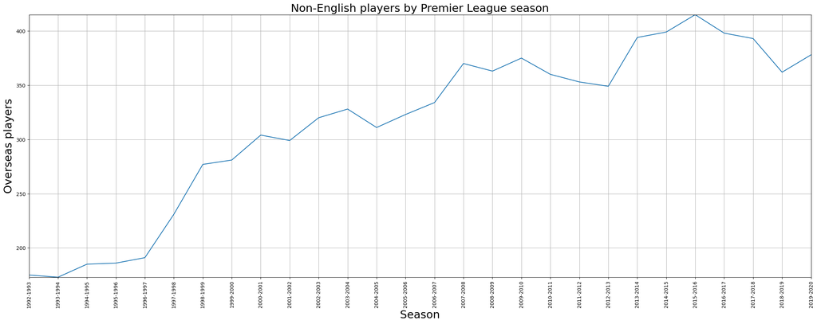

```python
# Plot the numbers
plt.rcParams['figure.figsize'] = [28, 10]
plt.rcParams['axes.grid'] = True
plt.xlabel('Season', fontsize=22)
plt.ylabel('Overseas players', fontsize=22)
plt.title('Non-English players by Premier League season', fontsize=22)
plt.plot(plot1.index, plot1['Overseas Players'])
plt.xticks(rotation='vertical')
plt.margins(0)
plt.subplots_adjust(bottom=0.15)
plt.show()
```

As we can see, the opening season of the Premier League saw 175 overseas (a nationality that is stated as being other than English) players feature in the competition's squads. After a slight drop the following year (to 173), this number increased almost consistently until it hit a high in the 2015-2016 season. We can get a clearer look at the most notable figures like so:

```python
plot1.describe()
```

|  | Overseas Players |
| --- | --- |
| count | 28.000000 |
| mean | 315.250000 |
| std | 75.852989 |
| min | 173.000000 |
| 25% | 280.000000 |
| 50% | 331.000000 |
| 75% | 371.250000 |
| max | 415.000000 |

We can see that the lowest amount of foreign players was 173, in season 1993-1994, while - as stated - it peaked at 415 in 2015-2016. The average amount of foreign players is ~315.

### Overseas players as a percentage of total players

The above, however interesting, does not give us the full story. What we really need to know is the number of overseas players as a percentage of the players involved in that season. The peak of 415 that we saw in the 2015-2016 season means little if that season saw the largest squad numbers on record for Premier League seasons. Let's see if we can get a more detailed analysis.

```python
# Get the aggregate count of all players for a season
plot2 = data.groupby(['Season'])[['Team']].agg(['count'])
plot2.columns = ['All Players']
plot2

# Merge this new data with our previous dataset
plot3 = pd.merge(plot1, plot2, on='Season')

# Now calculate the overseas players numbers as a percentage, and sort by that number
plot3['Overseas Percentage'] = round((plot3['Overseas Players'] / plot3['All Players']) * 100, 2)
plot3.sort_values(['Overseas Percentage'], ascending=False).style.bar(subset=['Overseas Percentage'], color='lightblue').set_properties(subset=['Overseas Percentage'], **{'width': '300px'})
```

| Season | Overseas Players | All Players | Overseas Percentage |
| --- | --- | --- | --- |
| 2013-2014 | 394 | 562 | 70.110000 |
| 2007-2008 | 370 | 550 | 67.270000 |
| 2009-2010 | 375 | 563 | 66.610000 |
| 2012-2013 | 349 | 536 | 65.110000 |
| 2006-2007 | 334 | 515 | 64.850000 |
| 2008-2009 | 363 | 562 | 64.590000 |
| 2005-2006 | 323 | 503 | 64.210000 |
| 2010-2011 | 360 | 563 | 63.940000 |
| 2017-2018 | 393 | 617 | 63.700000 |
| 2003-2004 | 328 | 519 | 63.200000 |
| 2011-2012 | 353 | 560 | 63.040000 |
| 2015-2016 | 415 | 659 | 62.970000 |
| 2018-2019 | 362 | 575 | 62.960000 |
| 2014-2015 | 399 | 638 | 62.540000 |
| 2004-2005 | 311 | 500 | 62.200000 |
| 2016-2017 | 398 | 643 | 61.900000 |
| 2002-2003 | 320 | 525 | 60.950000 |
| 2019-2020 | 378 | 621 | 60.870000 |
| 2001-2002 | 299 | 502 | 59.560000 |
| 2000-2001 | 304 | 533 | 57.040000 |
| 1999-2000 | 281 | 525 | 53.520000 |
| 1998-1999 | 277 | 524 | 52.860000 |
| 1997-1998 | 231 | 451 | 51.220000 |
| 1996-1997 | 191 | 431 | 44.320000 |
| 1995-1996 | 186 | 470 | 39.570000 |
| 1994-1995 | 185 | 520 | 35.580000 |
| 1992-1993 | 175 | 513 | 34.110000 |
| 1993-1994 | 173 | 509 | 33.990000 |

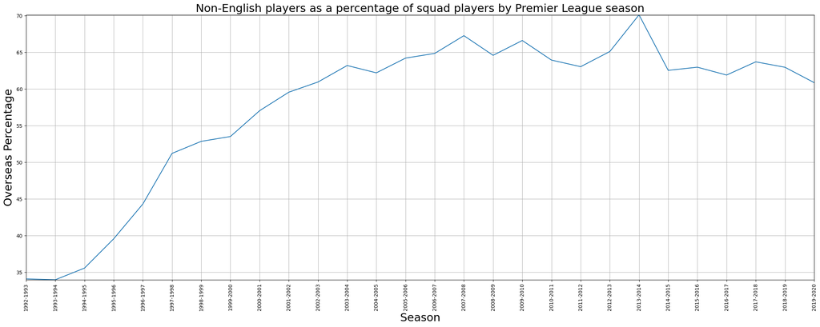

```python
# Plot the numbers
plt.rcParams['figure.figsize'] = [28, 10]
plt.rcParams['axes.grid'] = True
plt.xlabel('Season', fontsize=22)
plt.ylabel('Overseas Percentage', fontsize=22)
plt.title('Non-English players as a percentage of squad players by Premier League season', fontsize=22)
plt.plot(plot3.index, plot3['Overseas Percentage'])
plt.xticks(rotation='vertical')
plt.margins(0)
plt.subplots_adjust(bottom=0.15)
plt.show()
```

Let us take a quick look at the overall picture of the above data:

```python
plot3.describe()
```

|  | Overseas Players | All Players | Overseas Percentage |
| --- | --- | --- | --- |
| count | 28.000000 | 28.000000 | 28.000000 |
| mean | 315.250000 | 542.464286 | 57.599643 |
| std | 75.852989 | 55.606742 | 10.530562 |
| min | 173.000000 | 431.000000 | 33.990000 |
| 25% | 280.000000 | 512.000000 | 53.355000 |
| 50% | 331.000000 | 529.000000 | 62.370000 |
| 75% | 371.250000 | 563.000000 | 64.007500 |
| max | 415.000000 | 659.000000 | 70.110000 |

We can see by this that the Premier League really has been a magnet for overseas football players. The average percentage of non-English players playing in a Premier League season is a remarkable 57.6%, with the minumum almost 34% in the league's second season, and peaking - as discussed - at just over 70% in 2013-2014.

### A "league of nations on the pitch"

So we have seen that the Premier League has consistenly fielded a large number of overseas players in it's competition, an average of almost 60% of all it's players. But, as the Premier League itself claimed in 2013, can it be seen as a "league of nations on the pitch". Let's look at how the nations of the world are represented.

```python
# Get a total count of each nationality
plot4 = data.loc[~(data['Nationality'] == 'England')].groupby(['Nationality'])[['Nationality']].agg(['count'])
plot4.columns = ['Total players']
plot4.sort_values(['Total players'], ascending=False)
```

| Nationality | Total players |
| --- | --- |
| Republic of Ireland | 789 |
| France | 724 |
| Scotland | 643 |
| Wales | 507 |
| Netherlands | 410 |
| ... | ... |
| Uganda | 1 |
| Philippines | 1 |
| Faroe Islands | 1 |
| Guinea-Bissau | 1 |
| Afghanistan | 1 |

120 rows × 1 columns

A very impressive 120 nations have been represented in the Premier League so far. However, it should be noted that FBRef didn't display the nationality of every player that has competed in the Premier League. During the data capture, we replaced any missing nationality with 'NOT STATED'. Let's see how many were affected:

```python
# Find how many unique players in our dataset
plot5 = data.drop_duplicates(subset=['Name'])
print("Total number of players analysed:", plot5.shape[0])

# Get a total count unique players without a specified nationality
plot6 = data.loc[(data['Nationality'] == 'NOT STATED')].drop_duplicates(subset=['Name']).groupby(['Nationality'])[['Nationality']].agg(['count'])
plot6.columns = ['Total players']
plot6
```

```
Total number of players analysed: 4328
```

| Nationality | Total players |
| --- | --- |
| NOT STATED | 43 |

So of the 4328 players who have played in the Premier League since it's inception, we have 43 players whose nationality is unknown. It could be that there has been more than 120 nations represented. Out of interest, let's see the top 20 most represented countries.

```python
# Get a total count of each nationality, display the top 20
plot7 = data.loc[~(data['Nationality'] == 'England')].groupby(['Nationality'])[['Nationality']].agg(['count'])
plot7.columns = ['Total players']
plot7.sort_values(['Total players'], ascending=False).head(20).style.bar(subset=['Total players'], color='red').set_properties(subset=['Total players'], **{'width': '400px'})
```

| Nationality | Total players |
| --- | --- |
| Republic of Ireland | 789 |
| France | 724 |
| Scotland | 643 |
| Wales | 507 |
| Netherlands | 410 |
| Spain | 401 |
| Northern Ireland | 253 |
| Brazil | 245 |
| Norway | 235 |
| Argentina | 225 |
| Belgium | 196 |
| Denmark | 196 |
| Germany | 195 |
| Portugal | 188 |
| Australia | 186 |
| Italy | 183 |
| Nigeria | 182 |
| Sweden | 163 |
| United States | 163 |
| Jamaica | 154 |

It is perhaps of little surprise to see the Republic of Ireland, Scotland and Wales take three of the top four most represented countries. Northern Ireland sits at 7th. How about those lesser represented countries:

```python
# Get a total count of each nationality, display the bottom 10
plot8 = data.loc[~(data['Nationality'] == 'England')].groupby(['Nationality'])[['Nationality']].agg(['count'])
plot8.columns = ['Total players']
plot8.sort_values(['Total players'], ascending=False).tail(10).style.bar(subset=['Total players'], color='red').set_properties(subset=['Total players'], **{'width': '400px'})
```

| Nationality | Total players |
| --- | --- |
| Seychelles | 1 |
| Tanzania | 1 |
| Cape Verde | 1 |
| Central African Republic | 1 |
| Cuba | 1 |
| Uganda | 1 |
| Philippines | 1 |
| Faroe Islands | 1 |
| Guinea-Bissau | 1 |
| Afghanistan | 1 |

Very interesting to see such countries as Afghanistan, Cuba and Guinea-Bissau being represented.

Now let's take a closer look at each season to find which overseas nation was represented the most every year.

```python
# Decribe the nationality data
plot9 = data.loc[~(data['Nationality'] == 'England')].groupby(['Season'])[['Nationality']]
plot9.describe()
```

| Season | Nationality count | Nationality unique | Nationality top | Nationality freq |
| --- | --- | --- | --- | --- |
| 1992-1993 | 175 | 28 | Scotland | 38 |
| 1993-1994 | 173 | 27 | Scotland | 34 |
| 1994-1995 | 185 | 32 | Wales | 30 |
| 1995-1996 | 186 | 37 | Scotland | 32 |
| 1996-1997 | 191 | 37 | Scotland | 28 |
| 1997-1998 | 231 | 45 | Scotland | 28 |
| 1998-1999 | 277 | 55 | Scotland | 35 |
| 1999-2000 | 281 | 54 | Scotland | 30 |
| 2000-2001 | 304 | 64 | Scotland | 34 |
| 2001-2002 | 299 | 55 | France | 37 |
| 2002-2003 | 320 | 63 | France | 36 |
| 2003-2004 | 328 | 60 | France | 45 |
| 2004-2005 | 311 | 60 | France | 34 |
| 2005-2006 | 323 | 60 | France | 35 |
| 2006-2007 | 334 | 72 | Republic of Ireland | 24 |
| 2007-2008 | 370 | 71 | France | 29 |
| 2008-2009 | 363 | 74 | France | 34 |
| 2009-2010 | 375 | 72 | Republic of Ireland | 38 |
| 2010-2011 | 360 | 69 | Republic of Ireland | 34 |
| 2011-2012 | 353 | 72 | Republic of Ireland | 36 |
| 2012-2013 | 349 | 74 | France | 30 |
| 2013-2014 | 394 | 69 | France | 35 |
| 2014-2015 | 399 | 65 | France | 39 |
| 2015-2016 | 415 | 67 | France | 38 |
| 2016-2017 | 398 | 65 | Spain | 37 |
| 2017-2018 | 393 | 68 | Spain | 32 |
| 2018-2019 | 362 | 66 | Spain | 35 |
| 2019-2020 | 378 | 64 | Spain | 32 |

What can we infer from this information? Well, France was heavily represented at the turn of the century, which was around the time of Arsene Wenger's French revolution at Arsenal. France featured again from around 2013, when - among others - Newcastle United saw an influx of French players. Finally, we can see that Spain has been represented the most since 2016, having won the UEFA European Championship in 2008, 2012, the FIFA World Cup in 2010 and the UEFA European Under-21 Championship in 2011, 2013 and 2019. <sup>6</sup> <sup>7</sup> <sup>8</sup>

Looking at some of the countries that have been represented in the Premier League, I think it would be hard to disagree with the Premier League's claim that it has become a "league of nations on the pitch".

### Regional Differences

The Premier League has had teams compete in it's competition from every corner of England and Wales. From Newcastle to Bournemouth, and from Swansea to Norwich. Have overseas players featured heavily in all regions of England and Wales, or have they played more often in teams based in, for example, London? Let's see if we can find that out.

Firstly, let's take a look at the teams that have featured in the Premier League, and see who have fielded the most overseas players.

```python
# Get the number of overseas players (removing unknowns)
plot16 = data.loc[(~(data['Nationality'] == 'England')) & (~(data['Nationality'] == 'NOT STATED'))].groupby(['Team'])[['Nationality']].size().reset_index(name='counts')
# Get the total number of players
plot17 = data.groupby(['Team'])[['Nationality']].size().reset_index(name='counts')
# Merge the two datasets
plot18 = pd.merge(plot16, plot17, on=['Team'])
plot18.columns = ['Team', 'Overseas players', 'All players']

print("Total number of teams:", plot18.shape[0])
plot18.sort_values(['Overseas players'], ascending=False).style.bar(subset=['Overseas players'], color='pink').set_properties(subset=['Overseas players'], **{'width': '300px'})
```

```
Total number of teams: 49
```

|  | Team | Overseas players | All players |
| --- | --- | --- | --- |
| 13 | Chelsea | 527 | 751 |
| 0 | Arsenal | 500 | 753 |
| 26 | Manchester Utd | 448 | 759 |
| 24 | Liverpool | 438 | 713 |
| 42 | Tottenham | 404 | 762 |
| 28 | Newcastle Utd | 401 | 668 |
| 17 | Everton | 399 | 749 |
| 25 | Manchester City | 397 | 615 |
| 45 | West Ham | 387 | 698 |
| 18 | Fulham | 305 | 396 |
| 1 | Aston Villa | 296 | 622 |
| 39 | Sunderland | 295 | 469 |
| 4 | Blackburn | 280 | 450 |
| 37 | Southampton | 256 | 563 |
| 44 | West Brom | 213 | 334 |
| 6 | Bolton | 207 | 329 |
| 27 | Middlesbrough | 202 | 415 |
| 23 | Leicester City | 186 | 372 |
| 38 | Stoke City | 183 | 270 |
| 15 | Crystal Palace | 172 | 335 |
| 43 | Watford | 160 | 224 |
| 46 | Wigan Athletic | 157 | 208 |
| 40 | Swansea City | 136 | 198 |
| 32 | Portsmouth | 131 | 194 |
| 22 | Leeds United | 125 | 284 |
| 16 | Derby County | 124 | 195 |
| 29 | Norwich City | 116 | 231 |
| 48 | Wolves | 112 | 172 |
| 3 | Birmingham City | 110 | 192 |
| 12 | Charlton Ath | 106 | 204 |
| 14 | Coventry City | 103 | 226 |
| 20 | Hull City | 96 | 151 |
| 47 | Wimbledon | 90 | 188 |
| 10 | Burnley | 82 | 171 |
| 33 | QPR | 77 | 187 |
| 36 | Sheffield Weds | 72 | 192 |
| 7 | Bournemouth | 64 | 155 |
| 9 | Brighton | 59 | 86 |
| 34 | Reading | 53 | 77 |
| 30 | Nott'ham Forest | 52 | 118 |
| 21 | Ipswich Town | 42 | 116 |
| 35 | Sheffield Utd | 40 | 106 |
| 19 | Huddersfield | 38 | 60 |
| 11 | Cardiff City | 38 | 60 |
| 8 | Bradford City | 21 | 52 |
| 5 | Blackpool | 16 | 30 |
| 2 | Barnsley | 12 | 21 |
| 31 | Oldham Athletic | 10 | 44 |
| 41 | Swindon Town | 7 | 24 |

49 teams have competed in the Premier League since it's inception, and up until last season. Chelsea, based in West London, have fielded the most overseas players - a total of 527 - while Swindon Town, in the South West of England, have fielded only 7 overseas players. However, like before, this doesn't tell us the full story. Chelsea have featured in every Premier League season that has been played. Swindon Town have played in one season. Like before, we need to look at what percentage of a team's players have been overseas players.

But before we do that, with the help of Google, I have created a CSV file containing the UK government region for each of the 49 teams that have featured in the Premier League. Let's merge that data, so we have a more detailed picture.

```python
# Calculate the overseas player percentage of total players
plot19 = plot18.copy()
plot19['Overseas Percentage'] = round((plot18['Overseas players'] / plot18['All players']) * 100, 2)
# Read in region file
regionsdata = pd.read_csv('regions.csv', header=0)
# Merge with our dataset
plot20 = pd.merge(plot19, regionsdata, on=['Team'])
plot20.sort_values(['Overseas Percentage'], ascending=False).style.bar(subset=['Overseas Percentage'], color='yellow').set_properties(subset=['Overseas Percentage'], **{'width': '300px'})
```

|  | Team | Overseas players | All players | Overseas Percentage | Region |
| --- | --- | --- | --- | --- | --- |
| 18 | Fulham | 305 | 396 | 77.020000 | London |
| 46 | Wigan Athletic | 157 | 208 | 75.480000 | North West (England) |
| 43 | Watford | 160 | 224 | 71.430000 | East of England |
| 13 | Chelsea | 527 | 751 | 70.170000 | London |
| 34 | Reading | 53 | 77 | 68.830000 | South East (England) |
| 40 | Swansea City | 136 | 198 | 68.690000 | Wales |
| 9 | Brighton | 59 | 86 | 68.600000 | South East (England) |
| 38 | Stoke City | 183 | 270 | 67.780000 | West Midlands (England) |
| 32 | Portsmouth | 131 | 194 | 67.530000 | South East (England) |
| 0 | Arsenal | 500 | 753 | 66.400000 | London |
| 48 | Wolves | 112 | 172 | 65.120000 | West Midlands (England) |
| 25 | Manchester City | 397 | 615 | 64.550000 | North West (England) |
| 44 | West Brom | 213 | 334 | 63.770000 | West Midlands (England) |
| 16 | Derby County | 124 | 195 | 63.590000 | East Midlands (England) |
| 20 | Hull City | 96 | 151 | 63.580000 | Yorkshire and The Humber |
| 11 | Cardiff City | 38 | 60 | 63.330000 | Wales |
| 19 | Huddersfield | 38 | 60 | 63.330000 | Yorkshire and The Humber |
| 6 | Bolton | 207 | 329 | 62.920000 | North West (England) |
| 39 | Sunderland | 295 | 469 | 62.900000 | North East (England) |
| 4 | Blackburn | 280 | 450 | 62.220000 | North West (England) |
| 24 | Liverpool | 438 | 713 | 61.430000 | North West (England) |
| 28 | Newcastle Utd | 401 | 668 | 60.030000 | North East (England) |
| 26 | Manchester Utd | 448 | 759 | 59.030000 | North West (England) |
| 3 | Birmingham City | 110 | 192 | 57.290000 | West Midlands (England) |
| 2 | Barnsley | 12 | 21 | 57.140000 | Yorkshire and The Humber |
| 45 | West Ham | 387 | 698 | 55.440000 | London |
| 5 | Blackpool | 16 | 30 | 53.330000 | North West (England) |
| 17 | Everton | 399 | 749 | 53.270000 | North West (England) |
| 42 | Tottenham | 404 | 762 | 53.020000 | London |
| 12 | Charlton Ath | 106 | 204 | 51.960000 | London |
| 15 | Crystal Palace | 172 | 335 | 51.340000 | London |
| 29 | Norwich City | 116 | 231 | 50.220000 | East of England |
| 23 | Leicester City | 186 | 372 | 50.000000 | East Midlands (England) |
| 27 | Middlesbrough | 202 | 415 | 48.670000 | North East (England) |
| 10 | Burnley | 82 | 171 | 47.950000 | North West (England) |
| 47 | Wimbledon | 90 | 188 | 47.870000 | London |
| 1 | Aston Villa | 296 | 622 | 47.590000 | West Midlands (England) |
| 14 | Coventry City | 103 | 226 | 45.580000 | West Midlands (England) |
| 37 | Southampton | 256 | 563 | 45.470000 | South East (England) |
| 30 | Nott'ham Forest | 52 | 118 | 44.070000 | East Midlands (England) |
| 22 | Leeds United | 125 | 284 | 44.010000 | Yorkshire and The Humber |
| 7 | Bournemouth | 64 | 155 | 41.290000 | South West (England) |
| 33 | QPR | 77 | 187 | 41.180000 | London |
| 8 | Bradford City | 21 | 52 | 40.380000 | Yorkshire and The Humber |
| 35 | Sheffield Utd | 40 | 106 | 37.740000 | Yorkshire and The Humber |
| 36 | Sheffield Weds | 72 | 192 | 37.500000 | Yorkshire and The Humber |
| 21 | Ipswich Town | 42 | 116 | 36.210000 | East of England |
| 41 | Swindon Town | 7 | 24 | 29.170000 | South West (England) |
| 31 | Oldham Athletic | 10 | 44 | 22.730000 | North West (England) |

This gives us a more true reflection. Fulham, walking distance from Chelsea, now sit at the top, with 77% of the players they have fielded in the Premier League coming from overseas. Next is Wigan (the North West), then Watford (East of England), Chelsea (London) and Reading (South East). Four regions featuring in the top 5 places. At the bottom, we have two teams from Yorkshire and The Humber (the two Sheffield teams), one from the East of England (Ipswich Town), one from the South West (Swindon) and Oldham Athletic of the North West. A mixed picture.

How does this look on a interactive map of England and the UK? We'll take a map from the Office of National Statistics<sup>9</sup>, and add our data.

```python
# Get the number of overseas players (removing unknowns)
map1 = data.loc[(~(data['Nationality'] == 'England')) & (~(data['Nationality'] == 'NOT STATED'))].groupby(['Team'])[['Nationality']].size().reset_index(name='counts')
# Get the total number of players
map2 = data.groupby(['Team'])[['Nationality']].size().reset_index(name='counts')
# Merge the two datasets
map3 = pd.merge(map1, map2, on=['Team'])
map3.columns = ['Team', 'Overseas players', 'All players']
# Calculate percentage
map4 = map3.copy();
map4['Overseas Percentage'] = round((map3['Overseas players'] / map3['All players']) * 100, 2)
# Get a copy of the regions
regionsformap = regionsdata.copy();
# Merge with our dataset
merged = pd.merge(map4, regionsformap, on=['Team'])
# Calculate the average overseas player representation for each region
grouped = merged.groupby(['Region'])[['Overseas Percentage']].agg('mean')

# Load in the map
map_df = gpd.read_file("NUTS_Level_1__January_2018__Boundaries.shp")

# Rename dataset column to match map data
formap = grouped.reset_index().copy()
formap.columns = ['nuts118nm', 'AveragePercentage']

newmap_df = map_df.drop(['long', 'lat', 'nuts118cd', 'objectid', 'bng_e', 'bng_n', 'st_areasha', 'st_lengths'], axis=1)

# Merge our dataset with the map data
mapmerge = pd.merge(newmap_df, formap, on=['nuts118nm'])

# Input GeoJSON source for plotting
geosource = GeoJSONDataSource(geojson = mapmerge.to_json())

# Load palette
palette = Magma256
palette = palette[::-1]
colormap = LinearColorMapper(palette = palette, low = 0, high = 100)

# Define tick labels
ticklabels = {
    '0': '0',
    '10': '10',
    '20': '20',
    '30': '30',
    '40': '40',
    '50': '50',
    '60': '60',
    '70': '70',
    '80': '80',
    '90': '90',
    '100': '100'
}

# Create colour bar
colorbar = ColorBar(color_mapper = colormap,
                     label_standoff = 10,
                     width = 500,
                     height = 20,
                     border_line_color = None,
                     location = (0,0),
                     orientation = 'horizontal',
                     major_label_overrides = ticklabels)

# Create map
p = figure(title = 'Average overseas players percentage of total Premier League squads by region',
           plot_height = 800,
           plot_width = 800,
           tools = 'box_zoom, reset')
p.xgrid.grid_line_color = None
p.ygrid.grid_line_color = None
p.axis.visible = False
regions = p.patches('xs',
                    'ys',
                    source = geosource,
                    fill_color = {'field' :'AveragePercentage',
                                 'transform' : colormap},
                    line_color = 'gray',
                    line_width = 0.25,
                    fill_alpha = 1)
# Hovers
p.add_tools(HoverTool(renderers = [regions],
                      tooltips = [
                        ('Region','@nuts118nm'),
                        ('Average Percentage','@AveragePercentage')]))
p.add_layout(colorbar, 'below')
# Render
show(p)
```

[interactive chart not shown]

As we can now clearly see, it is Wales who have fielded the most overseas players as a percentage of their total Premier League squad numbers since the League began. Wales is followed by the South East, the West Midlands, the North East and then London. The South West and then Yorkshire and the Humber have fielded the least amount of overseas players as a percentage of their Premier League squads.

### Effects - Succcess and failure

We have seen that Premier League teams have always fielded a large number of overseas players, and that an incredible amount of nations have been represented in the league. But, other than giving us the opportunity to regularly watch some of the greatest players in the world, what effect has this had on the Premier League and it's teams in terms of success or failure?

To try and answer this question, let's find the team with the highest percentage of overseas players in their squad for each season of the Premier League, and look at their final league position for that season.

```python
# Highlight functions
def highlightRow(s, value, color1, color2, column):
    found = pd.Series(data=False, index=s.index)
    found[column] = s.loc[column] == value
    return [('background-color: %s' % color1) if found.any() else ('background-color: %s' % color2) for v in found]

def highlightLeaguePositions(s, column):
    found = pd.Series(data=False, index=s.index)
    found[column] = s.loc[column] == 1
    return [('background-color: red') if found.any() else ('') for v in found]

# Get the number of overseas players (removing unknowns)
plot10 = data.loc[(~(data['Nationality'] == 'England')) & (~(data['Nationality'] == 'NOT STATED'))].groupby(['Season', 'Team', 'Standing'])[['Nationality']].size().reset_index(name='counts')
# Get the total number of players
plot11 = data.groupby(['Season', 'Team', 'Standing'])[['Nationality']].size().reset_index(name='counts')
# Merge the two datasets
plot12 = pd.merge(plot10, plot11, on=['Team', 'Season'])
# Drop and rename columns
plot13 = plot12[['Season', 'Team', 'Standing_x', 'counts_x', 'counts_y']]
plot13.columns = ['Season', 'Team', 'League Position', 'Overseas players', 'All players']
# Calculate the overseas player percentage of total players
plot14 = plot13.copy()
plot14['Overseas Percentage'] = round((plot13['Overseas players'] / plot13['All players']) * 100, 2)
# Get the highest overseas player percentage of total players for each season
plot15 = plot14.groupby('Season')\
  .apply(lambda group: group[group['Overseas Percentage'] == group['Overseas Percentage'].max()])\
  .reset_index(drop=True)

plot15.style.apply(highlightLeaguePositions, column=['League Position'], axis=1)
```

|  | Season | Team | League Position | Overseas players | All players | Overseas Percentage |
| --- | --- | --- | --- | --- | --- | --- |
| 0 | 1992-1993 | Chelsea | 11 | 15 | 29 | 51.720000 |
| 1 | 1993-1994 | Chelsea | 14 | 15 | 26 | 57.690000 |
| 2 | 1994-1995 | Chelsea | 11 | 10 | 23 | 43.480000 |
| 3 | 1994-1995 | Manchester Utd | 2 | 10 | 23 | 43.480000 |
| 4 | 1995-1996 | Chelsea | 11 | 12 | 22 | 54.550000 |
| 5 | 1996-1997 | Chelsea | 6 | 14 | 24 | 58.330000 |
| 6 | 1997-1998 | Leeds United | 5 | 14 | 19 | 73.680000 |
| 7 | 1998-1999 | Newcastle Utd | 13 | 20 | 29 | 68.970000 |
| 8 | 1999-2000 | Chelsea | 5 | 20 | 27 | 74.070000 |
| 9 | 2000-2001 | Chelsea | 6 | 21 | 26 | 80.770000 |
| 10 | 2001-2002 | Newcastle Utd | 4 | 15 | 19 | 78.950000 |
| 11 | 2002-2003 | Fulham | 14 | 22 | 27 | 81.480000 |
| 12 | 2003-2004 | Chelsea | 2 | 21 | 27 | 77.780000 |
| 13 | 2004-2005 | Arsenal | 2 | 22 | 24 | 91.670000 |
| 14 | 2005-2006 | Arsenal | 4 | 24 | 27 | 88.890000 |
| 15 | 2006-2007 | Arsenal | 4 | 23 | 24 | 95.830000 |
| 16 | 2007-2008 | Arsenal | 3 | 25 | 27 | 92.590000 |
| 17 | 2008-2009 | Liverpool | 2 | 20 | 23 | 86.960000 |
| 18 | 2009-2010 | Blackburn | 10 | 23 | 27 | 85.190000 |
| 19 | 2010-2011 | Arsenal | 4 | 23 | 27 | 85.190000 |
| 20 | 2011-2012 | Arsenal | 3 | 27 | 32 | 84.380000 |
| 21 | 2012-2013 | Wigan Athletic | 18 | 25 | 28 | 89.290000 |
| 22 | 2013-2014 | Newcastle Utd | 10 | 21 | 26 | 80.770000 |
| 23 | 2014-2015 | Manchester City | 2 | 22 | 26 | 84.620000 |
| 24 | 2015-2016 | Watford | 13 | 30 | 33 | 90.910000 |
| 25 | 2016-2017 | Chelsea | 1 | 21 | 26 | 80.770000 |
| 26 | 2017-2018 | Manchester City | 1 | 20 | 26 | 76.920000 |
| 27 | 2018-2019 | Manchester City | 1 | 19 | 24 | 79.170000 |
| 28 | 2019-2020 | Watford | 19 | 22 | 30 | 73.330000 |

That said, it should be noted that on two occassions - Wigan Athletic in 2012-2013 and Watford last season - the team with the highest percentage of overseas players has actually been relegated. Note that there are 29 rows in the above table, as - in 1994-1995 - Chelsea and Manchester United had the same number of squad players and overseas players.

Let's plot this data on a graph.

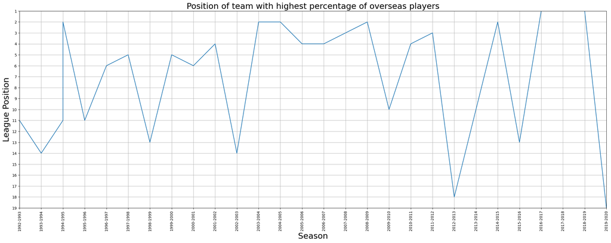

```python
# Plot the numbers
plt.rcParams['figure.figsize'] = [28, 10]
plt.rcParams['axes.grid'] = True
plt.xlabel('Season', fontsize=22)
plt.ylabel('League Position', fontsize=22)
plt.yticks([1,2,3,4,5,6,7,8,9,10,11,12,13,14,15,16,17,18,19,20])
plt.title('Position of team with highest percentage of overseas players', fontsize=22)
plt.plot(plot15['Season'], plot15['League Position'])
plt.xticks(rotation='vertical')
plt.margins(0)
plt.subplots_adjust(bottom=0.15)
plt.gca().invert_yaxis()
plt.show()
```

As you can see, there is no discernable pattern here, although one could note that on only two occassions has the team with the highest percentage of overseas players finished below 14th. Of course, as mentioned earlier, both of those teams were relegated.

As football pundits enjoy telling us over and over again, goals win games. With that in mind, let us look at the effect of overseas players on the Premier League in respect to goals. First, we'll look at each Premier League season's top scorer, inspecting their nationality.

```python
# Get the highest number of goals for each team
plot16 = data.groupby(['Season', 'Team', 'Name'])[['Goals']].agg('max')
# Add other columns that we want
plot17 = data[['Name', 'Season', 'Team', 'Nationality']]
# Merge the above
plot18 = pd.merge(plot16, plot17, on=['Name', 'Team', 'Season'])
# Now find the highest for each season
plot19 = plot18.groupby('Season')\
  .apply(lambda group: group[group['Goals'] == group['Goals'].max()])\
  .reset_index(drop=True)
# Show results
plot19.style.apply(highlightRow, value='England', color1='yellow', color2='lightgreen', column=['Nationality'], axis=1)
```

|  | Name | Team | Season | Goals | Nationality |
| --- | --- | --- | --- | --- | --- |
| 0 | Teddy Sheringham | Tottenham | 1992-1993 | 21 | England |
| 1 | Andy Cole | Newcastle Utd | 1993-1994 | 34 | England |
| 2 | Alan Shearer | Blackburn | 1994-1995 | 34 | England |
| 3 | Alan Shearer | Blackburn | 1995-1996 | 31 | England |
| 4 | Alan Shearer | Newcastle Utd | 1996-1997 | 25 | England |
| 5 | Chris Sutton | Blackburn | 1997-1998 | 18 | England |
| 6 | Dion Dublin | Coventry City | 1997-1998 | 18 | England |
| 7 | Michael Owen | Liverpool | 1997-1998 | 18 | England |
| 8 | Jimmy Floyd Hasselbaink | Leeds United | 1998-1999 | 18 | Netherlands |
| 9 | Dwight Yorke | Manchester Utd | 1998-1999 | 18 | Trinidad and Tobago |
| 10 | Kevin Phillips | Sunderland | 1999-2000 | 30 | England |
| 11 | Jimmy Floyd Hasselbaink | Chelsea | 2000-2001 | 23 | Netherlands |
| 12 | Thierry Henry | Arsenal | 2001-2002 | 24 | France |
| 13 | Ruud van Nistelrooy | Manchester Utd | 2002-2003 | 25 | Netherlands |
| 14 | Thierry Henry | Arsenal | 2003-2004 | 30 | France |
| 15 | Thierry Henry | Arsenal | 2004-2005 | 25 | France |
| 16 | Thierry Henry | Arsenal | 2005-2006 | 27 | France |
| 17 | Didier Drogba | Chelsea | 2006-2007 | 20 | Ivory Coast |
| 18 | Cristiano Ronaldo | Manchester Utd | 2007-2008 | 31 | Portugal |
| 19 | Nicolas Anelka | Chelsea | 2008-2009 | 19 | France |
| 20 | Didier Drogba | Chelsea | 2009-2010 | 29 | Ivory Coast |
| 21 | Carlos Tevez | Manchester City | 2010-2011 | 20 | Argentina |
| 22 | Dimitar Berbatov | Manchester Utd | 2010-2011 | 20 | Bulgaria |
| 23 | Robin van Persie | Arsenal | 2011-2012 | 30 | Netherlands |
| 24 | Robin van Persie | Manchester Utd | 2012-2013 | 26 | Netherlands |
| 25 | Luis Suárez | Liverpool | 2013-2014 | 31 | Uruguay |
| 26 | Sergio Agüero | Manchester City | 2014-2015 | 26 | Argentina |
| 27 | Harry Kane | Tottenham | 2015-2016 | 25 | England |
| 28 | Harry Kane | Tottenham | 2016-2017 | 29 | England |
| 29 | Mohamed Salah | Liverpool | 2017-2018 | 32 | Egypt |
| 30 | Pierre-Emerick Aubameyang | Arsenal | 2018-2019 | 22 | Gabon |
| 31 | Mohamed Salah | Liverpool | 2018-2019 | 22 | Egypt |
| 32 | Sadio Mané | Liverpool | 2018-2019 | 22 | Senegal |
| 33 | Jamie Vardy | Leicester City | 2019-2020 | 23 | England |

```python
# Remove duplicates
plot19.drop_duplicates(subset=['Name']).reset_index().style.apply(highlightRow, value='England',color1='yellow', color2='lightgreen', column=['Nationality'], axis=1)
```

|  | index | Name | Team | Season | Goals | Nationality |
| --- | --- | --- | --- | --- | --- | --- |
| 0 | 0 | Teddy Sheringham | Tottenham | 1992-1993 | 21 | England |
| 1 | 1 | Andy Cole | Newcastle Utd | 1993-1994 | 34 | England |
| 2 | 2 | Alan Shearer | Blackburn | 1994-1995 | 34 | England |
| 3 | 5 | Chris Sutton | Blackburn | 1997-1998 | 18 | England |
| 4 | 6 | Dion Dublin | Coventry City | 1997-1998 | 18 | England |
| 5 | 7 | Michael Owen | Liverpool | 1997-1998 | 18 | England |
| 6 | 8 | Jimmy Floyd Hasselbaink | Leeds United | 1998-1999 | 18 | Netherlands |
| 7 | 9 | Dwight Yorke | Manchester Utd | 1998-1999 | 18 | Trinidad and Tobago |
| 8 | 10 | Kevin Phillips | Sunderland | 1999-2000 | 30 | England |
| 9 | 12 | Thierry Henry | Arsenal | 2001-2002 | 24 | France |
| 10 | 13 | Ruud van Nistelrooy | Manchester Utd | 2002-2003 | 25 | Netherlands |
| 11 | 17 | Didier Drogba | Chelsea | 2006-2007 | 20 | Ivory Coast |
| 12 | 18 | Cristiano Ronaldo | Manchester Utd | 2007-2008 | 31 | Portugal |
| 13 | 19 | Nicolas Anelka | Chelsea | 2008-2009 | 19 | France |
| 14 | 21 | Carlos Tevez | Manchester City | 2010-2011 | 20 | Argentina |
| 15 | 22 | Dimitar Berbatov | Manchester Utd | 2010-2011 | 20 | Bulgaria |
| 16 | 23 | Robin van Persie | Arsenal | 2011-2012 | 30 | Netherlands |
| 17 | 25 | Luis Suárez | Liverpool | 2013-2014 | 31 | Uruguay |
| 18 | 26 | Sergio Agüero | Manchester City | 2014-2015 | 26 | Argentina |
| 19 | 27 | Harry Kane | Tottenham | 2015-2016 | 25 | England |
| 20 | 29 | Mohamed Salah | Liverpool | 2017-2018 | 32 | Egypt |
| 21 | 30 | Pierre-Emerick Aubameyang | Arsenal | 2018-2019 | 22 | Gabon |
| 22 | 32 | Sadio Mané | Liverpool | 2018-2019 | 22 | Senegal |
| 23 | 33 | Jamie Vardy | Leicester City | 2019-2020 | 23 | England |

Let's do the same for assists, the second most important statistic for any outfield player in the Premier League. This time we'll only look at individual players.

```python
# Get the highest number of assists for each team
plot20 = data.groupby(['Season', 'Team', 'Name'])[['Assists']].agg('max')
# Add other columns that we want
plot21 = data[['Name', 'Season', 'Team', 'Nationality']]
# Merge the above
plot22 = pd.merge(plot20, plot21, on=['Name', 'Team', 'Season'])
# Now find the highest for each season
plot23 = plot22.groupby('Season')\
  .apply(lambda group: group[group['Assists'] == group['Assists'].max()])\
  .reset_index(drop=True)

# Remove duplicates and display
plot23.drop_duplicates(subset=['Name']).reset_index().style.apply(highlightRow, value='England', color1='yellow', color2='lightgreen', column=['Nationality'], axis=1)
```

|  | index | Name | Team | Season | Assists | Nationality |
| --- | --- | --- | --- | --- | --- | --- |
| 0 | 0 | Steve McManaman | Liverpool | 1992-1993 | 11 | England |
| 1 | 1 | Niall Quinn | Manchester City | 1992-1993 | 11 | Republic of Ireland |
| 2 | 2 | Matt Le Tissier | Southampton | 1992-1993 | 11 | England |
| 3 | 3 | Darren Anderton | Tottenham | 1992-1993 | 11 | England |
| 4 | 4 | Chris Sutton | Norwich City | 1993-1994 | 17 | England |
| 5 | 5 | Bryan Roy | Nott'ham Forest | 1994-1995 | 17 | Netherlands |
| 6 | 6 | Ryan Giggs | Manchester Utd | 1995-1996 | 16 | Wales |
| 7 | 7 | Neal Ardley | Wimbledon | 1996-1997 | 13 | England |
| 8 | 8 | David Beckham | Manchester Utd | 1997-1998 | 13 | England |
| 9 | 9 | Dennis Bergkamp | Arsenal | 1998-1999 | 12 | Netherlands |
| 10 | 10 | Steve Guppy | Leicester City | 1998-1999 | 12 | England |
| 11 | 13 | Laurent Robert | Newcastle Utd | 2001-2002 | 16 | France |
| 12 | 14 | Thierry Henry | Arsenal | 2002-2003 | 20 | France |
| 13 | 15 | Steed Malbranque | Fulham | 2003-2004 | 13 | France |
| 14 | 16 | Muzzy Izzet | Leicester City | 2003-2004 | 13 | Turkey |
| 15 | 18 | Frank Lampard | Chelsea | 2004-2005 | 16 | England |
| 16 | 19 | Didier Drogba | Chelsea | 2005-2006 | 11 | Ivory Coast |
| 17 | 20 | Cristiano Ronaldo | Manchester Utd | 2006-2007 | 13 | Portugal |
| 18 | 21 | Ashley Young | Aston Villa | 2007-2008 | 16 | England |
| 19 | 22 | Robin van Persie | Arsenal | 2008-2009 | 10 | Netherlands |
| 20 | 25 | Nani | Manchester Utd | 2010-2011 | 14 | Portugal |
| 21 | 26 | David Silva | Manchester City | 2011-2012 | 15 | Spain |
| 22 | 27 | Juan Mata | Chelsea | 2012-2013 | 12 | Spain |
| 23 | 28 | Steven Gerrard | Liverpool | 2013-2014 | 14 | England |
| 24 | 29 | Cesc Fàbregas | Chelsea | 2014-2015 | 18 | Spain |
| 25 | 30 | Mesut Özil | Arsenal | 2015-2016 | 19 | Germany |
| 26 | 31 | Kevin De Bruyne | Manchester City | 2016-2017 | 17 | Belgium |
| 27 | 33 | Eden Hazard | Chelsea | 2018-2019 | 15 | Belgium |

Let us return to goals. We've seen how many times the Premier League's top scorer has been an overseas player, but that tells us about the league itself - what about the effect, on goals, by overseas players for each individual team? Let's see if we can find out how many teams that have featured in the Premier League can point to an overseas player when hailing their team's most prolific player in the competition.

```python
# Get the highest number of goals for each team
plot24 = data.groupby(['Name', 'Team'])[['Goals']].sum()
# Add other columns that we want
plot25 = data[['Name', 'Team', 'Nationality']]
# Merge the two
plot26 = pd.merge(plot24, plot25, on=['Name', 'Team'])
# Group by team and get highest scorer
plot27 = plot26.groupby('Team')\
  .apply(lambda group: group[group['Goals'] == group['Goals'].max()])\
  .reset_index(drop=True)
# Remove duplicates and display
plot27.drop_duplicates(subset=['Team']).reset_index(drop=True).style.apply(highlightRow, value='England', color1='lightblue', color2='orange', column=['Nationality'], axis=1)
```

|  | Name | Team | Goals | Nationality |
| --- | --- | --- | --- | --- |
| 0 | Thierry Henry | Arsenal | 175 | France |
| 1 | Gabby Agbonlahor | Aston Villa | 74 | England |
| 2 | Neil Redfearn | Barnsley | 10 | England |
| 3 | Mikael Forssell | Birmingham City | 29 | Finland |
| 4 | Alan Shearer | Blackburn | 112 | England |
| 5 | DJ Campbell | Blackpool | 13 | England |
| 6 | Kevin Davies | Bolton | 67 | England |
| 7 | Joshua King | Bournemouth | 48 | Norway |
| 8 | Dean Windass | Bradford City | 10 | England |
| 9 | Glenn Murray | Brighton | 26 | England |
| 10 | Ashley Barnes | Burnley | 38 | England |
| 11 | Jordon Mutch | Cardiff City | 7 | England |
| 12 | Jason Euell | Charlton Ath | 34 | Jamaica |
| 13 | Frank Lampard | Chelsea | 147 | England |
| 14 | Dion Dublin | Coventry City | 62 | England |
| 15 | Wilfried Zaha | Crystal Palace | 36 | Ivory Coast |
| 16 | Dean Sturridge | Derby County | 31 | England |
| 17 | Romelu Lukaku | Everton | 68 | Belgium |
| 18 | Clint Dempsey | Fulham | 50 | United States |
| 19 | Steve Mounié | Huddersfield | 9 | Benin |
| 20 | Nikica Jelavić | Hull City | 13 | Croatia |
| 21 | Marcus Stewart | Ipswich Town | 25 | England |
| 22 | Mark Viduka | Leeds United | 59 | Australia |
| 23 | Jamie Vardy | Leicester City | 103 | England |
| 24 | Robbie Fowler | Liverpool | 126 | England |
| 25 | Sergio Agüero | Manchester City | 180 | Argentina |
| 26 | Wayne Rooney | Manchester Utd | 183 | England |
| 27 | Hamilton Ricard | Middlesbrough | 31 | Colombia |
| 28 | Alan Shearer | Newcastle Utd | 148 | England |
| 29 | Chris Sutton | Norwich City | 33 | England |
| 30 | Bryan Roy | Nott'ham Forest | 24 | Netherlands |
| 31 | Graeme Sharp | Oldham Athletic | 16 | Scotland |
| 32 | Yakubu Aiyegbeni | Portsmouth | 29 | Nigeria |
| 33 | Les Ferdinand | QPR | 60 | England |
| 34 | Kevin Doyle | Reading | 19 | Republic of Ireland |
| 35 | Brian Deane | Sheffield Utd | 14 | England |
| 36 | Mark Bright | Sheffield Weds | 49 | England |
| 37 | Matt Le Tissier | Southampton | 100 | England |
| 38 | Peter Crouch | Stoke City | 45 | England |
| 39 | Kevin Phillips | Sunderland | 61 | England |
| 40 | Gylfi Sigurðsson | Swansea City | 34 | Iceland |
| 41 | Jan Åge Fjørtoft | Swindon Town | 12 | Norway |
| 42 | Harry Kane | Tottenham | 143 | England |
| 43 | Troy Deeney | Watford | 47 | England |
| 44 | Peter Odemwingie | West Brom | 30 | Nigeria |
| 45 | Paolo Di Canio | West Ham | 52 | Italy |
| 46 | Hugo Rodallega | Wigan Athletic | 24 | Colombia |
| 47 | Dean Holdsworth | Wimbledon | 58 | England |
| 48 | Raúl Jiménez | Wolves | 30 | Mexico |

So of the 49 teams that have competed in the Premier League, 22 clubs have an overseas player as their greatest ever Premier League goal scorer. Again, let's do that for assists.

```python
# Get the highest number of assists for each team
plot28 = data.groupby(['Name', 'Team'])[['Assists']].sum()
# Add other columns that we want
plot29 = data[['Name', 'Team', 'Nationality']]
# Merge the two
plot30 = pd.merge(plot28, plot29, on=['Name', 'Team'])
# Group by team and get highest scorer
plot31 = plot30.groupby('Team')\
  .apply(lambda group: group[group['Assists'] == group['Assists'].max()])\
  .reset_index(drop=True)
# Remove duplicates and display
plot31.drop_duplicates(subset=['Team']).reset_index(drop=True).style.apply(highlightRow, value='England', color1='lightblue', color2='orange', column=['Nationality'], axis=1)
```

|  | Name | Team | Assists | Nationality |
| --- | --- | --- | --- | --- |
| 0 | Dennis Bergkamp | Arsenal | 92 | Netherlands |
| 1 | Ashley Young | Aston Villa | 48 | England |
| 2 | Nicky Eaden | Barnsley | 3 | England |
| 3 | Stan Lazaridis | Birmingham City | 14 | Australia |
| 4 | Morten Gamst Pedersen | Blackburn | 44 | Norway |
| 5 | Charlie Adam | Blackpool | 8 | Scotland |
| 6 | Kevin Davies | Bolton | 39 | England |
| 7 | Ryan Fraser | Bournemouth | 26 | Scotland |
| 8 | Peter Beagrie | Bradford City | 5 | England |
| 9 | Pascal Groß | Brighton | 15 | Germany |
| 10 | Jóhann Berg Guðmundsson | Burnley | 17 | Iceland |
| 11 | Peter Whittingham | Cardiff City | 6 | England |
| 12 | Claus Jensen | Charlton Ath | 15 | Denmark |
| 13 | Frank Lampard | Chelsea | 91 | England |
| 14 | Gary McAllister | Coventry City | 17 | Scotland |
| 15 | Wilfried Zaha | Crystal Palace | 22 | Ivory Coast |
| 16 | Dean Sturridge | Derby County | 12 | England |
| 17 | Leighton Baines | Everton | 54 | England |
| 18 | Steed Malbranque | Fulham | 31 | France |
| 19 | Aaron Mooy | Huddersfield | 4 | Australia |
| 20 | Ahmed Elmohamady | Hull City | 9 | Egypt |
| 21 | John Wark | Ipswich Town | 9 | Scotland |
| 22 | Harry Kewell | Leeds United | 37 | Australia |
| 23 | Steve Guppy | Leicester City | 37 | England |
| 24 | Steven Gerrard | Liverpool | 100 | England |
| 25 | David Silva | Manchester City | 93 | Spain |
| 26 | Ryan Giggs | Manchester Utd | 191 | Wales |
| 27 | Stewart Downing | Middlesbrough | 35 | England |
| 28 | Nolberto Solano | Newcastle Utd | 54 | Peru |
| 29 | Chris Sutton | Norwich City | 20 | England |
| 30 | Bryan Roy | Nott'ham Forest | 21 | Netherlands |
| 31 | Graeme Sharp | Oldham Athletic | 6 | Scotland |
| 32 | Matthew Taylor | Portsmouth | 14 | England |
| 33 | Les Ferdinand | QPR | 18 | England |
| 34 | Nicky Shorey | Reading | 17 | England |
| 35 | Brian Deane | Sheffield Utd | 8 | England |
| 36 | Chris Waddle | Sheffield Weds | 29 | England |
| 37 | Matt Le Tissier | Southampton | 72 | England |
| 38 | Matthew Etherington | Stoke City | 25 | England |
| 39 | Adam Johnson | Sunderland | 17 | England |
| 40 | Gylfi Sigurðsson | Swansea City | 29 | Iceland |
| 41 | Paul Bodin | Swindon Town | 6 | Wales |
| 42 | Darren Anderton | Tottenham | 67 | England |
| 43 | Troy Deeney | Watford | 20 | England |
| 44 | Chris Brunt | West Brom | 48 | Northern Ireland |
| 45 | Mark Noble | West Ham | 35 | England |
| 46 | Charles N'Zogbia | Wigan Athletic | 12 | France |
| 47 | Neal Ardley | Wimbledon | 31 | England |
| 48 | João Moutinho | Wolves | 14 | Portugal |

## Conclusions

We have seen that overseas players have always been an important, indeed, essential part of the English Premier League.

After 175 overseas players took park in the inaugural season of the Premier League, representing 34% of that season's squad members, the number of overseas players has increased almost consistenly, hitting a peak in the 2013-2014 season when overseas players accounted for a huge 70% of all squad members. If we consider the slight drop in numbers in the league's second season, we can perhaps point to the Bosman ruling in 1995 after which the numbers began to increase. We saw that after the start of the 2010-2011 season, and the beginning of the Homegrown Player initiative, the following two seasons saw a slight drop in the number of overseas players, but that those numbers soon recovered, increasing dramatically for the start of the 2013-2014 season. Finally, we were able to determine that when we look at every club squad for every season of the Premier League so far, the average percentage of non-English players playing in a Premier League season is almost 58%.

While the team with the highest number percentage of overseas players in a season has won the Premier League on only three occassions, it was noted that only twice in 28 seasons has a team with the highest percentage finished lower than 14 - although both teams suffered relegation. Delving deeper into these figures, we can see that while Watford finished 13th in 2015-2016 with almost 91% of their players being overseas players, no other team fielding 90+% overseas players has finished lower than a very impressive **fourth** place.

Examining the spread of overseas players throughout the regions of England and Wales, that have made up the membership of the Premier League, it was found - surprisingly - that it is Wales who have fielded a larger total percentage of overseas players in their squads than any other region. Furthermore, London also sits behind the South East, the West Midlands and the North East in overseas player numbers, despite Fulham having fielded the highest percentage of overseas players, pushing past 70%.

Overall, I think what we have found is that one the most compelling reasons that the English Premier League is the greatest in the world is because of its overseas talent. We have been lucky enough to enjoy the best years of players such as Henry, Drogba, Agüero and Bergkamp and witnessed the rise of players like Cristiano Ronaldo, De Bruyne and Salah. That said, this author's bias aside, Alan Shearer remains the Premier League's most prolific and greatest goal scorer.

## Further Work

To extend the analysis further, it would be interesting to look at minutes on the pitch - have the figures been skewed by overseas squad players who signed contracts with Premier League sides, but then didn't make an impact and failed to make regular appearances?

It might also be compelling to look at player's positions. Have overseas players dominated a particular area of the pitch? Do we see more overseas defenders than overseas midfielders? Do teams field more overseas strikers than they do English strikers? I am struggling to remember a Premier League season when football fans would name an English player when discussing the league's best goalkeeper.

Finally, although I'm unclear where this data could be sourced, I would very much enjoy looking further into the argument that a proliferation of overseas players has damaged grassroots football and made it more difficult for *homegrown* players to break into Premier League sides. I would like to get the data from Premier League clubs' academies - those that have them - and analyse how they have been affected by the overseas transfer market.

## References

1 Premier League. Wikipedia. https://en.wikipedia.org/wiki/Premier_League

2 Bosman ruling. Wikipedia. https://en.wikipedia.org/wiki/Bosman_ruling

3 Premier League - What we do (Web Archive 2013) https://web.archive.org/web/20130819085500/https://www.premierleague.com/content/premierleague/en-gb/about/what-we-do.html

4 Homegrown Player Rule (England). Wikipedia. https://en.wikipedia.org/wiki/Homegrown_Player_Rule_(England))

5 About Sports Reference. Sports Reference. https://www.sports-reference.com/about.html

6 UEFA European Championships. Wikipedia. https://en.wikipedia.org/wiki/UEFA_European_Championship

7 FIFA World Cup. Wikipedia. https://en.wikipedia.org/wiki/FIFA_World_Cup

8 UEFA European Under-21 Championship. Wikipedia. https://en.wikipedia.org/wiki/UEFA_European_Under-21_Championship

9 NUTS_Level_1_(January_2018)_Full_Clipped_Boundaries_in_the_United_Kingdom. Office of National Statistics. https://geoportal.statistics.gov.uk/datasets/nuts-level-1-january-2018-boundaries?layer=0

## Version Control Log

```python
!git log --oneline --decorate --reverse
```

```
fatal: not a git repository (or any of the parent directories): .git
```

```python
!pip freeze > requirements_new.txt
```